# Tutorial Acitivity 5

Sean Leggett - BDA201 - Winter 2020  
March 2, 2020

## Question

Is there a linear relationship between the age at which a child first begins to speak and his or her mental ability later on? To answer this question a study was conducted in which the age (in months) at which a child first spoke and the child’s score on an aptitude test as a teenager were recorded:

Age 14, 26, 10, 9, 15, 20, 17, 11, 8, 20

Score 96, 71, 83, 91, 99, 87, 93, 100, 104, 94

Answer the following questions using R (where applicable)

Draw a scatterplot and determine whether there appears to be a linear relationship between these two variables. What is the relationship, how would you describe it? Calculate and show covariance Calculate and show Pearson correlation coefficient r Determine and show what percentage of the variability in the aptitude score can be explained by the variability in the age at which a child begins speaking.

## Answer

Scatterplot:

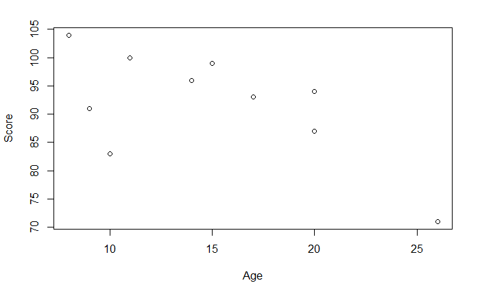

```r
##create df
agescore <- data.frame('Age' = c(14, 26, 10, 9, 15, 20, 17, 11, 8, 20),
                       'Score' = c(96, 71, 83, 91, 99, 87, 93, 100, 104, 94)
)

agescoreplot <- plot(agescore)
```

```r
agescoreplot
```

Calculate Covariance

```r
age <- agescore$Age
score <- agescore$Score
agecov <- cov(score, age)
agecov
```

```
[1] -34.77778
```

Calculate Pearson Correlation Coefficient

```r
coftest <- cor.test(age, score, method = "pearson")
coftest
```

```
    Pearson's product-moment correlation

data:  age and score
t = -2.2755, df = 8, p-value = 0.05244
alternative hypothesis: true correlation is not equal to 0
95 percent confidence interval:
 -0.900902305  0.004604594
sample estimates:
      cor
-0.626839
```

Demonstrate what percentage of variability in aptitude scores can be explained by variability in age:

This could be demonstrated by assuming r = 0.626839, therefore r-squared = :

```r
variability <- 0.626839 * 0.626839
variability
```

```
[1] 0.3929271
```

39% of the variability in aptitude scores can be explained by variability in age.